# Intensify of degree adverbs: Experiment 8

erin

I ran 20 participants on an experiment where I showed them comics where either the word “truly” or the word “very” was used **22 times** (that’s twice as many times as in experiment 8a). The target question was:

[figure not shown]

I also asked how many times participants thought the speaker would use “truly” and “very”.

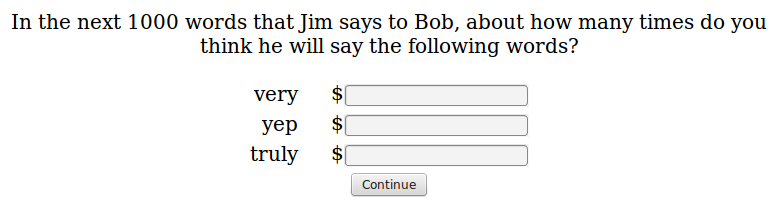

This time the stories successfully manipulated participants’ frequency estimates. Particpants give higher estimates for how often the speaker Jim will use a word if it is the target word (used 22 times in training) than if it is the control (used 0 times in training).

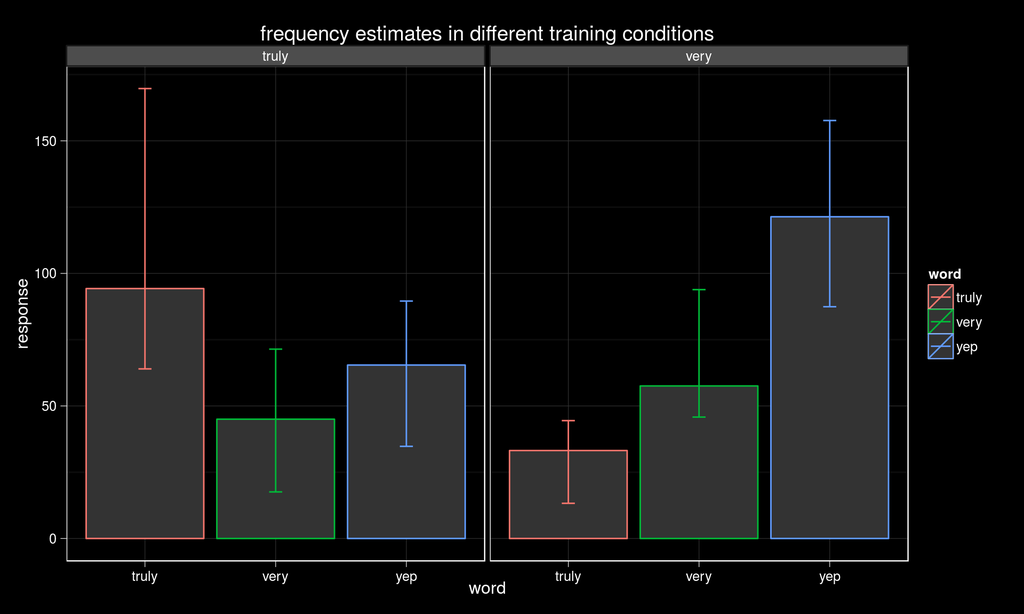

In the raw data, this results (at least numerically) in the target word being assigned a less strong meaning.

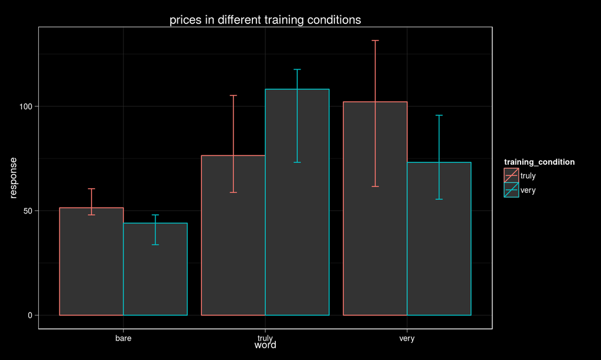

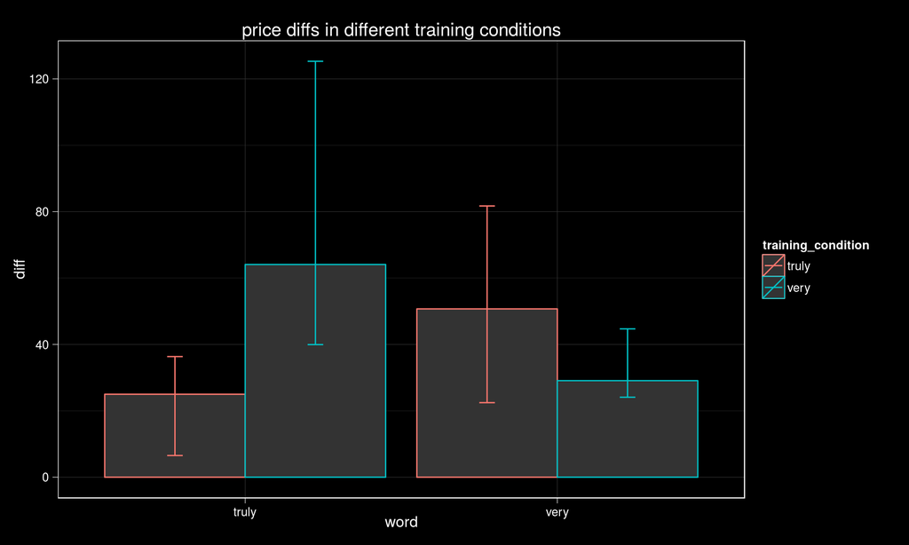

Overall, there’s a correlation of 0.3958 between surprisal (calculated from participants’ estmate of the frequency of the word) and the log of their price estimate.

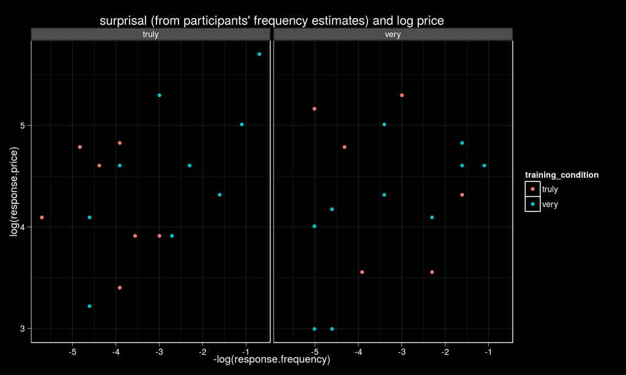